# March 7, 2022

```python
import matplotlib.pyplot as plt
import numpy as np
```

## List unpacking

```python
mylist = [1,2,3]

a = mylist[0]
b = mylist[1]
c = mylist[2]
```

```python
print(a)
print(b)
print(c)
```

```
1
2
3
```

```python
mylist = [1,2,3]
x,y,z = mylist
```

```python
print(x)
print(y)
print(z)
```

```
1
2
3
```

```python
mylist2 = [5]

x = mylist2
print(x)
```

```
[5]
```

```python
x, = mylist2
print(x)
```

```
5
```

## Multiple outputs from a function

```python
def f(a,b,c):
    return a**2, b + 1, a*b*c
```

```python
x,y,z = f(2,3,1)
```

```python
print(x)
print(y)
print(z)
```

```
4
4
6
```

```python
def f(a,b,c):
    return [a**2, b+1, a*b*c]
```

```python
x,y,z = f(2,3,1)
```

```python
print(x)
print(y)
print(z)
```

```
4
4
6
```

## Modifying plots

```python
import matplotlib.pyplot as plt
```

```python
%matplotlib notebook
```

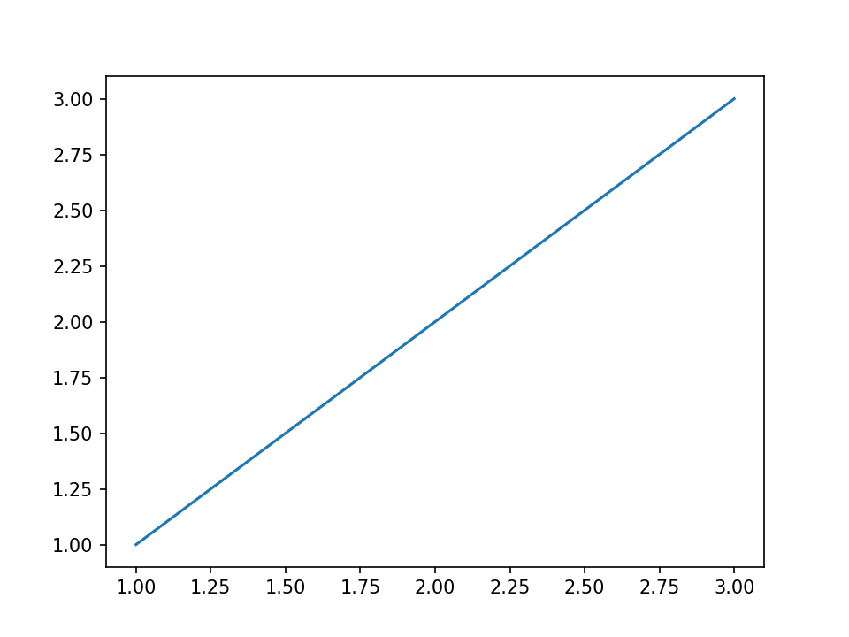

```python
plt.plot([1,2,3],[1,2,3])
plt.show()
```

```python
%matplotlib inline
```

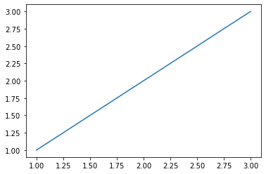

```python
plt.plot([1,2,3],[1,2,3])
plt.show()
```

For interactive plotting, we'll want to store the `figure` output and any `axes` that we generate. Let's start by plotting a circle in an interactive window.

```python
import numpy as np
```

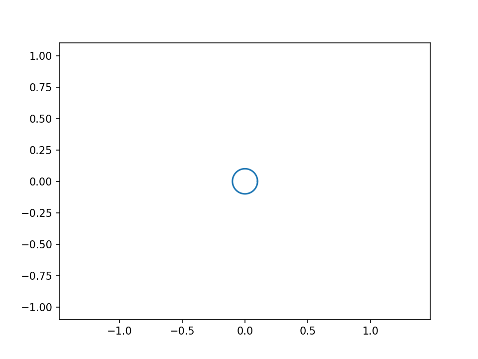

```python
fig = plt.figure()

plt.axis('equal')

t = np.linspace(0,2*np.pi,500)

x = np.cos(t)
y = np.sin(t)

p, = plt.plot(x,y)

plt.show()
```

We now have a figure object, `fig`, and a line plot, `p`. Now we'll start modifying the plot.

We can update the $x$ data using the `.set_xdata` method, and the $y$ data using the `.set_ydata` method.

The `.canvas.draw()` method for figure objects will update the figure.

```python
for r in np.linspace(1,0.1,100):
    p.set_xdata(r*x)
    p.set_ydata(r*y)
    fig.canvas.draw()
```

## The slider widget

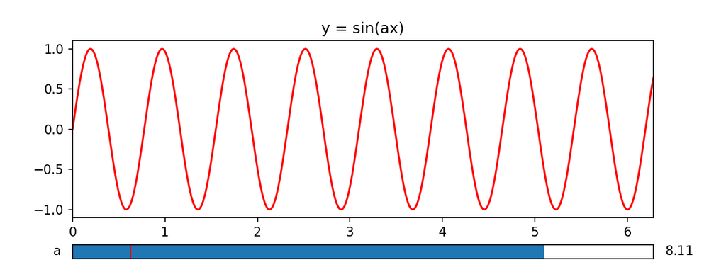

```python
from matplotlib.widgets import Slider  # import the Slider widget

import numpy as np
import matplotlib.pyplot as plt
from math import pi

a_min = 0    # the minimial value of the paramater a
a_max = 10   # the maximal value of the paramater a
a_init = 1   # the value of the parameter a to be used initially, when the graph is created

x = np.linspace(0, 2*pi, 500)

fig = plt.figure(figsize=(8,3))

# first we create the general layount of the figure
# with two axes objects: one for the plot of the function
# and the other for the slider
sin_ax = plt.axes([0.1, 0.2, 0.8, 0.65])
slider_ax = plt.axes([0.1, 0.05, 0.8, 0.05])


# in plot_ax we plot the function with the initial value of the parameter a
plt.axes(sin_ax) # select sin_ax
plt.title('y = sin(ax)')
sin_plot, = plt.plot(x, np.sin(a_init*x), 'r')
plt.xlim(0, 2*pi)
plt.ylim(-1.1, 1.1)

# here we create the slider
a_slider = Slider(slider_ax,      # the axes object containing the slider
                  'a',            # the name of the slider parameter
                  a_min,          # minimal value of the parameter
                  a_max,          # maximal value of the parameter
                  valinit=a_init  # initial value of the parameter
                 )

# Next we define a function that will be executed each time the value
# indicated by the slider changes. The variable of this function will
# be assigned the value of the slider.
def update(a):
    sin_plot.set_ydata(np.sin(a*x)) # set new y-coordinates of the plotted points
    fig.canvas.draw_idle()          # redraw the plot

# the final step is to specify that the slider needs to
# execute the above function when its value changes
a_slider.on_changed(update)

plt.show()
```

Variant:

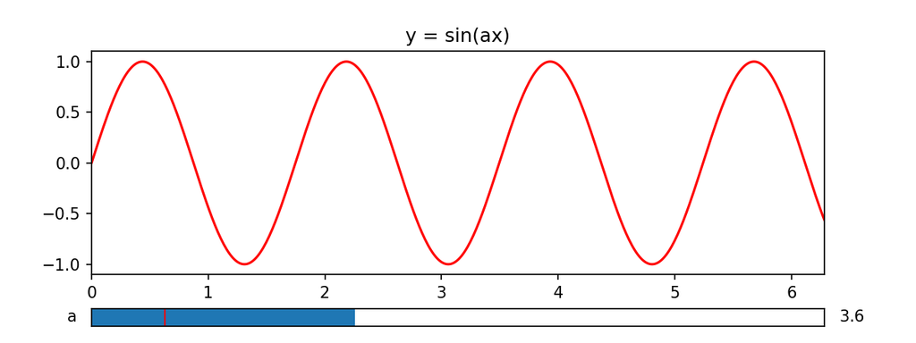

```python
from matplotlib.widgets import Slider  # import the Slider widget

import numpy as np
import matplotlib.pyplot as plt
from math import pi

a_min = 0    # the minimial value of the paramater a
a_max = 10   # the maximal value of the paramater a
a_init = 1   # the value of the parameter a to be used initially, when the graph is created

x = np.linspace(0, 2*pi, 500)

fig = plt.figure(figsize=(8,3))

# first we create the general layount of the figure
# with two axes objects: one for the plot of the function
# and the other for the slider
sin_ax = plt.axes([0.1, 0.2, 0.8, 0.65])
slider_ax = plt.axes([0.1, 0.05, 0.8, 0.05])


# in plot_ax we plot the function with the initial value of the parameter a
plt.axes(sin_ax) # select sin_ax
plt.title('y = sin(ax)')
sin_plot, = plt.plot(x, np.sin(a_init*x), 'r')
plt.xlim(0, 2*pi)
plt.ylim(-1.1, 1.1)

# here we create the slider
a_slider = Slider(slider_ax,      # the axes object containing the slider
                  'a',            # the name of the slider parameter
                  a_min,          # minimal value of the parameter
                  a_max,          # maximal value of the parameter
                  valinit=a_init  # initial value of the parameter
                 )

# Next we define a function that will be executed each time the value
# indicated by the slider changes. The variable of this function will
# be assigned the value of the slider.
def update(a):
    sin_plot.set_ydata(np.sin(a_slider.val*x)) # set new y-coordinates of the plotted points
    fig.canvas.draw_idle()          # redraw the plot

# the final step is to specify that the slider needs to
# execute the above function when its value changes
a_slider.on_changed(update)

plt.show()
```

Lissajous curves are curves given by the parametric equations $$ x = \sin(at) $$ $$ y = \cos(bt) $$

Create an interactive plot with sliders for the parameters $a$ and $b$ to generate Lissajous curves.

Suggestion:

1. First, modify the above code to plot a Lissajous curve with $b$ fixed and $a$ controlled by the existing slider.
2. Then introduce a second slider for the $b$ parameter.

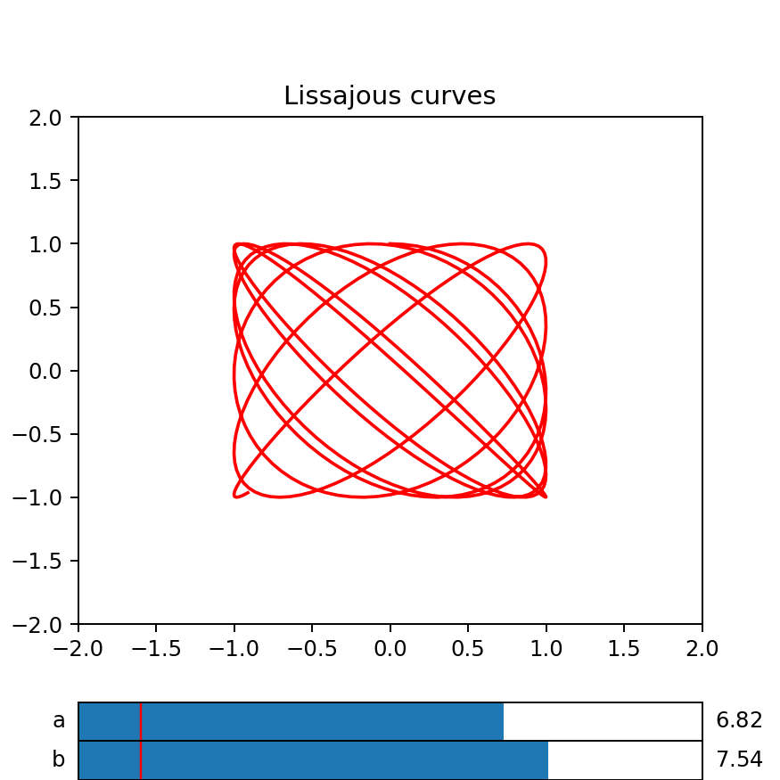

```python
from matplotlib.widgets import Slider  # import the Slider widget

import numpy as np
import matplotlib.pyplot as plt
from math import pi

a_min = 0    # the minimial value of the paramater a
a_max = 10   # the maximal value of the paramater a
a_init = 1   # the value of the parameter a to be used initially, when the graph is created

b_min = 0    # the minimial value of the paramater b
b_max = 10   # the maximal value of the paramater b
b_init = 1   # the value of the parameter b to be used initially, when the graph is created

t = np.linspace(0, 2*pi, 500)

fig = plt.figure(figsize=(5,5))

# first we create the general layount of the figure
# with two axes objects: one for the plot of the function
# and the other for the slider
liss_ax = plt.axes([0.1, 0.2, 0.8, 0.65])
a_slider_ax = plt.axes([0.1, 0.05, 0.8, 0.05])
b_slider_ax = plt.axes([0.1, 0, 0.8, 0.05])


# in plot_ax we plot the function with the initial value of the parameter a
plt.axes(liss_ax) # select sin_ax
plt.title('Lissajous curves')
liss_plot, = plt.plot(np.sin(a_init*t),np.cos(b_init*t), 'r')
plt.xlim(-2, 2)
plt.ylim(-2, 2)

# here we create the slider
a_slider = Slider(a_slider_ax,      # the axes object containing the slider
                  'a',            # the name of the slider parameter
                  a_min,          # minimal value of the parameter
                  a_max,          # maximal value of the parameter
                  valinit=a_init  # initial value of the parameter
                 )

b_slider = Slider(b_slider_ax,      # the axes object containing the slider
                  'b',            # the name of the slider parameter
                  b_min,          # minimal value of the parameter
                  b_max,          # maximal value of the parameter
                  valinit=b_init  # initial value of the parameter
                 )

# Next we define a function that will be executed each time the value
# indicated by the slider changes. The variable of this function will
# be assigned the value of the slider.
def update(a):
    liss_plot.set_xdata(np.sin(a_slider.val*t)) # set new y-coordinates of the plotted points
    liss_plot.set_ydata(np.cos(b_slider.val*t))
    fig.canvas.draw_idle()          # redraw the plot

# the final step is to specify that the slider needs to
# execute the above function when its value changes
a_slider.on_changed(update)
b_slider.on_changed(update)

plt.show()
```

```python
%matplotlib notebook
```

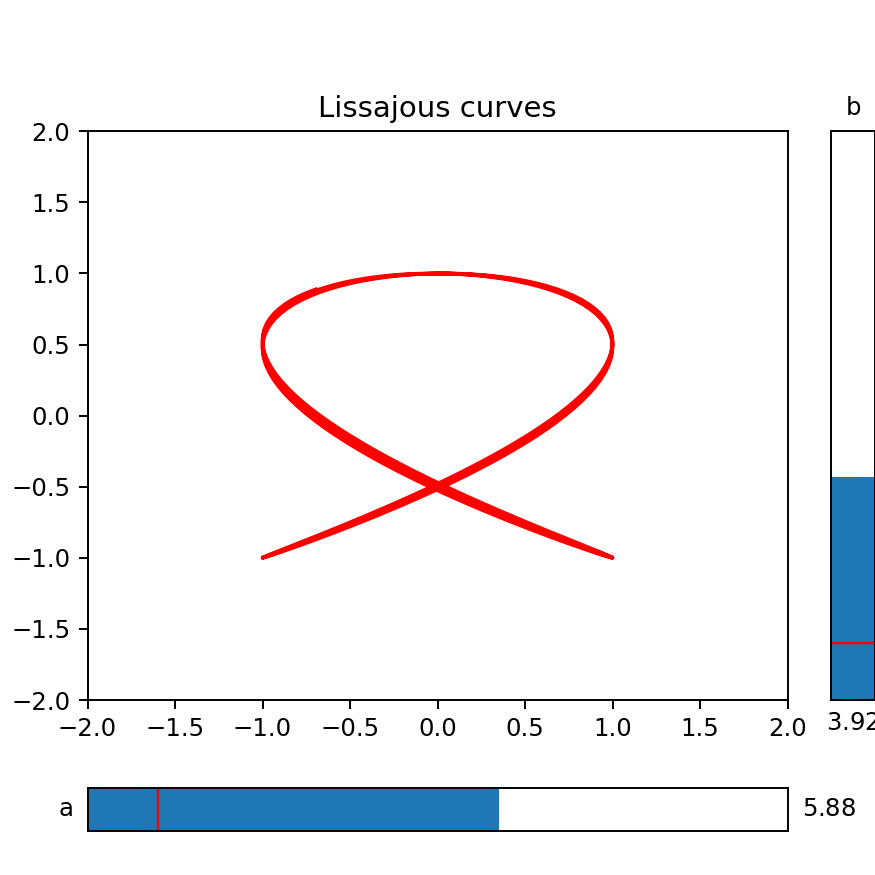

```python
from matplotlib.widgets import Slider  # import the Slider widget

import numpy as np
import matplotlib.pyplot as plt
from math import pi

a_min = 0    # the minimial value of the paramater a
a_max = 10   # the maximal value of the paramater a
a_init = 1   # the value of the parameter a to be used initially, when the graph is created

b_min = 0    # the minimial value of the paramater b
b_max = 10   # the maximal value of the paramater b
b_init = 1   # the value of the parameter b to be used initially, when the graph is created

t = np.linspace(0, 2*pi, 500)

fig = plt.figure(figsize=(5,5))

# first we create the general layount of the figure
# with two axes objects: one for the plot of the function
# and the other for the slider
liss_ax = plt.axes([0.1, 0.2, 0.8, 0.65])
a_slider_ax = plt.axes([0.1, 0.05, 0.8, 0.05])
b_slider_ax = plt.axes([0.95, .2, 0.05, 0.65])


# in plot_ax we plot the function with the initial value of the parameter a
plt.axes(liss_ax) # select sin_ax
plt.title('Lissajous curves')
liss_plot, = plt.plot(np.sin(a_init*t),np.cos(b_init*t), 'r')
plt.xlim(-2, 2)
plt.ylim(-2, 2)

# here we create the slider
a_slider = Slider(a_slider_ax,      # the axes object containing the slider
                  'a',            # the name of the slider parameter
                  a_min,          # minimal value of the parameter
                  a_max,          # maximal value of the parameter
                  valinit=a_init  # initial value of the parameter
                 )

b_slider = Slider(b_slider_ax,      # the axes object containing the slider
                  'b',            # the name of the slider parameter
                  b_min,          # minimal value of the parameter
                  b_max,          # maximal value of the parameter
                  valinit=b_init, # initial value of the parameter
                  orientation='vertical'
                 )

# Next we define a function that will be executed each time the value
# indicated by the slider changes. The variable of this function will
# be assigned the value of the slider.
def update(a):
    liss_plot.set_xdata(np.sin(a_slider.val*t)) # set new y-coordinates of the plotted points
    liss_plot.set_ydata(np.cos(b_slider.val*t))
    fig.canvas.draw_idle()          # redraw the plot

# the final step is to specify that the slider needs to
# execute the above function when its value changes
a_slider.on_changed(update)
b_slider.on_changed(update)

plt.show()
```

# March 9, 2022

Last time we introduced the `Slider` widget.

Today, we'll look at the `Button` widget.

**Exercise.**

Modify our code for Lissajous curves to intially plot a circle with radius 1 (in black), which will not change. We want two sliders that control the $x$- and $y$-position of a target.

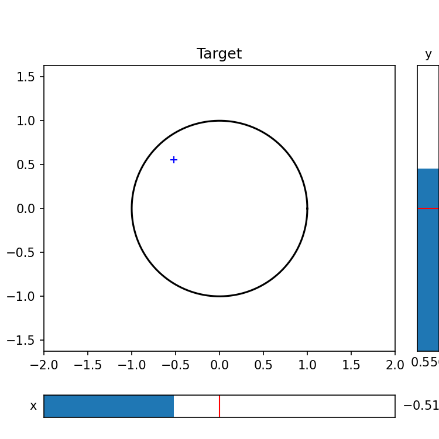

```python
from matplotlib.widgets import Slider  # import the Slider widget

import numpy as np
import matplotlib.pyplot as plt
from math import pi

x_min = -2    # the minimial value of the paramater a
x_max = 2   # the maximal value of the paramater a
x_init = 0   # the value of the parameter a to be used initially, when the graph is created

y_min = -2    # the minimial value of the paramater b
y_max = 2   # the maximal value of the paramater b
y_init = 0   # the value of the parameter b to be used initially, when the graph is created

t = np.linspace(0, 2*pi, 500)
R = 1

fig = plt.figure(figsize=(5,5))

# first we create the general layount of the figure
# with two axes objects: one for the plot of the function
# and the other for the slider
target_ax = plt.axes([0.1, 0.2, 0.8, 0.65])
x_slider_ax = plt.axes([0.1, 0.05, 0.8, 0.05])
y_slider_ax = plt.axes([0.95, .2, 0.05, 0.65])


# in plot_ax we plot the function with the initial value of the parameter a
plt.axes(target_ax) # select sin_ax
plt.title('Target')
target_plot, = plt.plot(x_init,y_init, 'b+')

# Add a circle target
plt.plot(R*np.cos(t),R*np.sin(t),'k')
plt.axis('equal')

plt.xlim(x_min, x_max)
plt.ylim(y_min, y_max)

# here we create the slider
x_slider = Slider(x_slider_ax,      # the axes object containing the slider
                  'x',            # the name of the slider parameter
                  x_min,          # minimal value of the parameter
                  x_max,          # maximal value of the parameter
                  valinit=x_init  # initial value of the parameter
                 )

y_slider = Slider(y_slider_ax,      # the axes object containing the slider
                  'y',            # the name of the slider parameter
                  y_min,          # minimal value of the parameter
                  y_max,          # maximal value of the parameter
                  valinit=y_init, # initial value of the parameter
                  orientation='vertical'
                 )

# Next we define a function that will be executed each time the value
# indicated by the slider changes. The variable of this function will
# be assigned the value of the slider.
def update(a):
    target_plot.set_xdata(x_slider.val) # set new y-coordinates of the plotted points
    target_plot.set_ydata(y_slider.val)
    fig.canvas.draw_idle()          # redraw the plot

# the final step is to specify that the slider needs to
# execute the above function when its value changes
x_slider.on_changed(update)
y_slider.on_changed(update)

plt.show()
```

Now, let's add a button that checks whether the crosshair is in the circle or not, and plot a dot that indicates whether it is a hit or a miss.

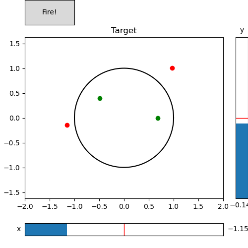

```python
from matplotlib.widgets import Slider  # import the Slider widget
from matplotlib.widgets import Button

import numpy as np
import matplotlib.pyplot as plt
from math import pi

x_min = -2    # the minimial value of the paramater a
x_max = 2   # the maximal value of the paramater a
x_init = 0   # the value of the parameter a to be used initially, when the graph is created

y_min = -2    # the minimial value of the paramater b
y_max = 2   # the maximal value of the paramater b
y_init = 0   # the value of the parameter b to be used initially, when the graph is created

t = np.linspace(0, 2*pi, 500)
R = 1

fig = plt.figure(figsize=(5,5))

# first we create the general layount of the figure
# with two axes objects: one for the plot of the function
# and the other for the slider
target_ax = plt.axes([0.1, 0.2, 0.8, 0.65])
x_slider_ax = plt.axes([0.1, 0.05, 0.8, 0.05])
y_slider_ax = plt.axes([0.95, .2, 0.05, 0.65])
button_ax = plt.axes([.1,.9,.2,.1])

# in plot_ax we plot the function with the initial value of the parameter a
plt.axes(target_ax) # select sin_ax
plt.title('Target')
target_plot, = plt.plot(x_init,y_init, 'b+')

# Add a circle target
plt.plot(R*np.cos(t),R*np.sin(t),'k')
plt.axis('equal')

plt.xlim(x_min, x_max)
plt.ylim(y_min, y_max)

# here we create the slider
x_slider = Slider(x_slider_ax,      # the axes object containing the slider
                  'x',            # the name of the slider parameter
                  x_min,          # minimal value of the parameter
                  x_max,          # maximal value of the parameter
                  valinit=x_init  # initial value of the parameter
                 )

y_slider = Slider(y_slider_ax,      # the axes object containing the slider
                  'y',            # the name of the slider parameter
                  y_min,          # minimal value of the parameter
                  y_max,          # maximal value of the parameter
                  valinit=y_init, # initial value of the parameter
                  orientation='vertical'
                 )

fire_button = Button(button_ax,'Fire!')

# Next we define a function that will be executed each time the value
# indicated by the slider changes. The variable of this function will
# be assigned the value of the slider.
def update(a):
    target_plot.set_xdata(x_slider.val) # set new y-coordinates of the plotted points
    target_plot.set_ydata(y_slider.val)
    fig.canvas.draw_idle()          # redraw the plot

def update_button(event):
    x = x_slider.val
    y = y_slider.val

    hit = (x**2 + y**2 < R**2)
    if hit:
        plt.plot(x,y,'go')
    else:
        plt.plot(x,y,'ro')

# the final step is to specify that the slider needs to
# execute the above function when its value changes
x_slider.on_changed(update)
y_slider.on_changed(update)
fire_button.on_clicked(update_button)

plt.show()
```

## Mayfly model

We want to model a mayfly population using the equation:

$$ y_n = b(1 - y_{n-1})y_{n-1}$$

for some $0 \leq b \leq 4$.

**Recall:** The $y$ variable has been re-scaled to lie between $0 \leq y \leq 1$.

```python
def mayfly(y0,b,N):
    ylist = [y0]
    for n in range(N):
        y_old = ylist[-1]
        y_new = b*(1-y_old)*y_old
        ylist.append(y_new)
    return ylist
```

```python
y0 = .2             # initial population
b = 3.2             # growth rate
N = 20              # number of time slices to model

ylist = mayfly(y0,b,N)
```

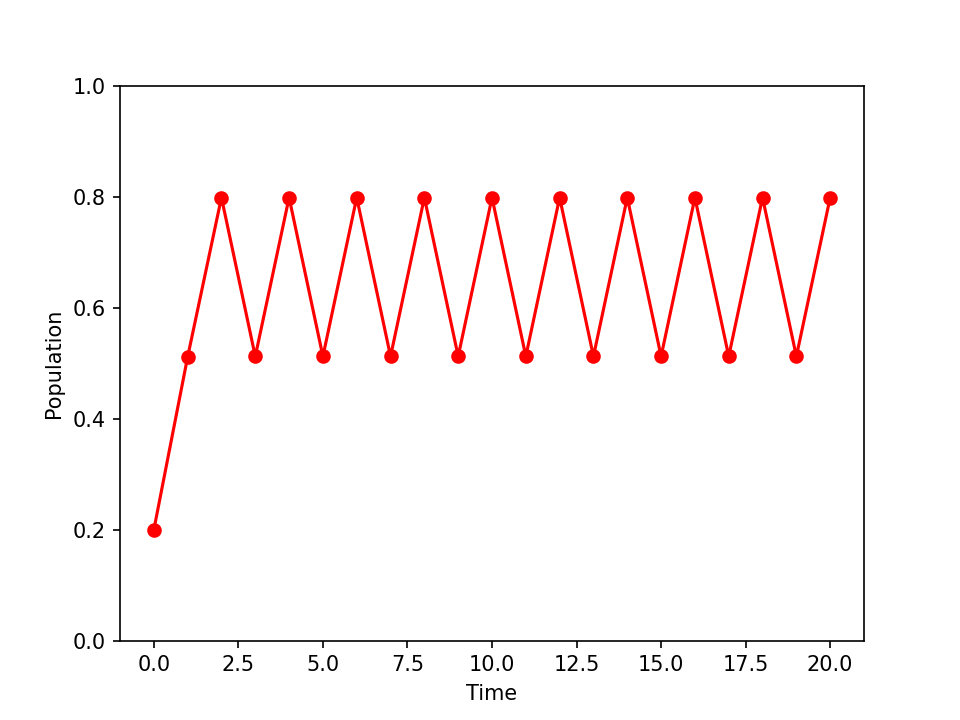

```
(0.0, 1.0)
```

```python
plt.figure()

plt.plot(ylist,'r-o')
plt.xlabel('Time')
plt.ylabel('Population')

plt.ylim(0,1)
```

**Exercise.** Modify the Lissajous double-slider code above to plot the mayfly population where `y0` and `b` are controlled by sliders.